# 中心极限定理

王思雨 冯洋洋 甘鹏程

2017年10月22日

# 一、中心极限定理验证

## 定义验证中心极限定理函数

函数默认值为实验次数为10,30,50,100次，每次试验抽取样本100个，利用0-1的均匀分布，

```r
central <- function(n = c(10, 30, 50, 100), d = "runif", a = 1, b = 0) {
    if (length(n) == 1)
        par(mfrow = c(1, 1))
    if (length(n) == 2)
        par(mfrow = c(1, 2))
    if (length(n) >= 3)
        par(mfrow = c(2, 2))  #根据向量大小分割作图框
    if (d == "runif") {
        for (i in 1:length(n)) {
            x <- matrix(runif(n[i] * 100, b, a), n[i], 100)
            s <- apply(x, 1, sum)  #1是行，2是列
            m = (a + b)/2  #计算均匀分布均值
            sd = (b - a)^2/12  #计算均匀分布方差
            s <- (s - 100 * m)/(sqrt(n[i]) * sqrt(sd))
            hist(s, xlim = c(-5, 5), ylim = c(0, 0.5), probability = T, col = "lightblue",
                main = "均匀分布验证中心极限定理")
            lines(density(s, bw = 1), col = "blue", lwd = 3)
            y <- seq(-5, 5, length.out = 100)
            lines(y, dnorm(y, 0, 1), col = "red", lwd = 3)  #增加一条正态密度曲线
            legend("topright", c("标准正态", "核密度估计"), lwd = 2, col = c("red",
                "blue"), cex = 0.6)  #增加图例
        }
    }
    if (d == "rt") {
        if (a <= 2)
            stop("自由度要大于2")
        for (i in 1:length(n)) {
            x <- matrix(rt(n[i] * 100, a, b), n[i], 100)
            s <- apply(x, 1, sum)  #1是行，2是列
            m = 0  #计算t分布均值
            sd = a/(a - 2)  #计算t分布方差
            s <- (s - 100 * m)/(sqrt(n[i]) * sqrt(sd))
            hist(s, xlim = c(-5, 5), ylim = c(0, 0.5), probability = T, col = "lightblue",
                main = "t分布验证中心极限定理")
            lines(density(s, bw = 1), col = "blue", lwd = 3)
            y <- seq(-5, 5, length.out = 100)
            lines(y, dnorm(y, 0, 1), col = "red", lwd = 3)  #增加一条正态密度曲线
            legend("topright", c("标准正态", "核密度估计"), lwd = 2, col = c("red",
                "blue"), cex = 0.6)  #增加图例
        }
    }
    if (d == "rf") {
        if (b <= 4)
            stop("第二自由度要大于4")
        for (i in 1:length(n)) {
            x <- matrix(rf(n[i] * 100, a, b, 0), n[i], 100)
            s <- apply(x, 1, sum)  #1是行，2是列
            m = b/(b - 2)  #计算f分布均值
            sd = 2 * b^2 * (a + b - 2)/a * (b - 2)^2 * (b - 4)  #计算f分布方差
            s <- (s - 100 * m)/(sqrt(n[i]) * sqrt(sd))
            hist(s, xlim = c(-5, 5), ylim = c(0, 0.5), probability = T, col = "lightblue",
                main = "F分布验证中心极限定理")
            lines(density(s, bw = 1), col = "blue", lwd = 3)
            y <- seq(-5, 5, length.out = 100)
            lines(y, dnorm(y, 0, 1), col = "red", lwd = 3)  #增加一条正态密度曲线
            legend("topright", c("标准正态", "核密度估计"), lwd = 2, col = c("red",
                "blue"), cex = 0.6)  #增加图例
        }
    }
    if (d == "rexp") {
        for (i in 1:length(n)) {
            x <- matrix(rexp(n[i] * 100, a), n[i], 100)
            s <- apply(x, 1, sum)  #1是行，2是列
            m = 1/a  #计算指数分布均值
            sd = 1/a^2  #计算指数分布方差
            s <- (s - 100 * m)/(sqrt(n[i]) * sqrt(sd))
            hist(s, xlim = c(-5, 5), ylim = c(0, 0.5), probability = T, col = "lightblue",
                main = "指数分布验证中心极限定理")
            lines(density(s, bw = 1), col = "blue", lwd = 3)
            y <- seq(-5, 5, length.out = 100)
            lines(y, dnorm(y, 0, 1), col = "red", lwd = 3)  #增加一条正态密度曲线
            legend("topright", c("标准正态", "核密度估计"), lwd = 2, col = c("red",
                "blue"), cex = 0.6)  #增加图例
        }
    }
    if (d == "rbinom") {
        for (i in 1:length(n)) {
            x <- matrix(rbinom(n[i] * 100, 1, a), n[i], 100)
            s <- apply(x, 1, sum)  #1是行，2是列
            m = a  #计算二项分布均值
            sd = 100 * a * (1 - a)  #计算二项分布方差
            s <- (s - 100 * m)/(sqrt(n[i]) * sqrt(sd))
            hist(s, xlim = c(-5, 5), ylim = c(0, 0.5), probability = T, col = "lightblue",
                main = "二项分布验证中心极限定理")
            lines(density(s, bw = 1), col = "blue", lwd = 3)
            y <- seq(-5, 5, length.out = 100)
            lines(y, dnorm(y, 0, 1), col = "red", lwd = 3)  #增加一条正态密度曲线
            legend("topright", c("标准正态", "核密度估计"), lwd = 2, col = c("red",
                "blue"), cex = 0.6)  #增加图例
        }
    }
}
```

## 根据不同分布验证中心极限定理

### 均匀分布的验证

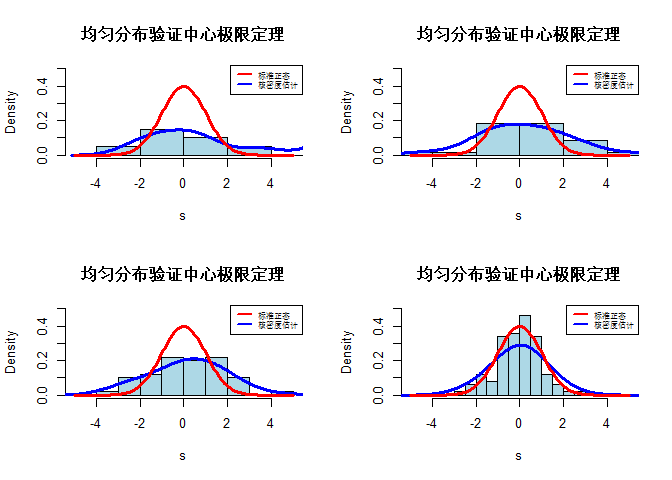

```r
central()  #利用默认值进行验证
```

### t分布的验证

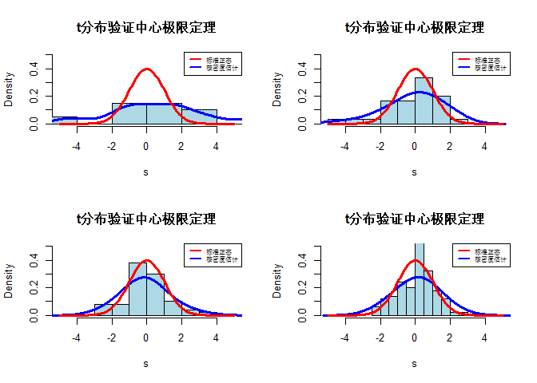

```r
shiyan = c(10, 30, 50, 100)  #实验次数为分别为10,30,50,100，每次试验抽取样本100次
central(shiyan, "rt", 5)  #利用自由度为5的t分布进行验证
```

### t分布的验证

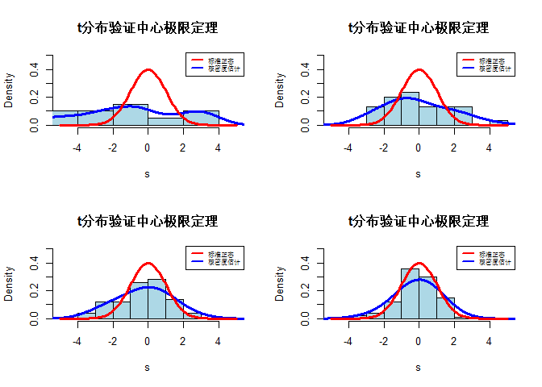

```r
shiyan = c(10, 30, 50, 100)  #实验次数为分别为10,30,50,100，每次试验抽取样本100次
central(shiyan, "rt", 5)  #利用自由度为5的t分布进行验证
```

### 指数分布的验证

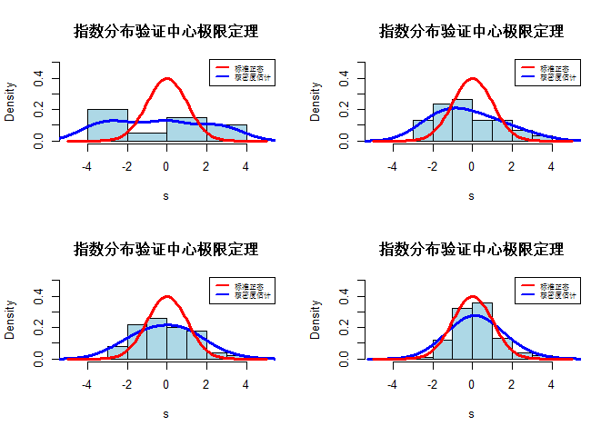

```r
shiyan = c(10, 30, 50, 100)  #实验次数为分别为10,30,50,100，每次试验抽取样本100次
central(shiyan, "rexp", 0.5)  #利用均值为2的指数分布进行验证
```

### 二项分布的验证

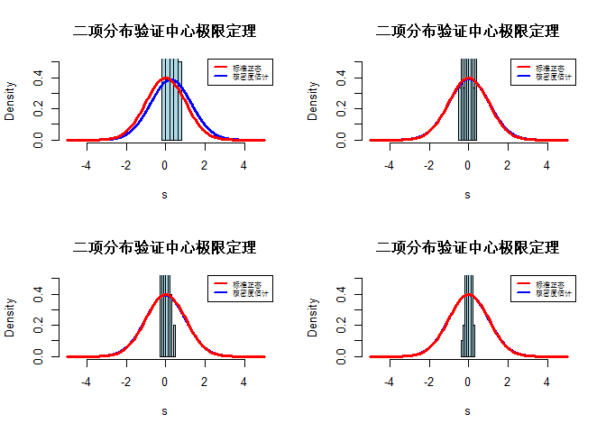

```r
shiyan = c(10, 30, 50, 100)  #实验次数为分别为10,30,50,100，每次试验抽取样本100次
central(shiyan, "rbinom", 0.4)  #利用二项分布进行验证
```

# 二、多功能绘图函数

## 定义函数

```r
#data:prefer a data frame or a vector of characters or numbers.
#by:aggregate by this vector
#type:which type of plot you want to make.
#main:the mail title of your plot.
#xlab:same as in plot.
#ylab:same as in plot.
#prob:in histplot,if you want a histplot with probability,set prob = TRUE
#type you can input:scatterplot,barplot,histplot,boxplot,pie
intelPlot<-function(data,by = NULL,type = NULL,aggreFun = NULL,main = NULL,xlab = NULL,ylab = NULL,prob = FALSE,addlines = FALSE)
{
  if(!is.null(data) & is.null(by))
  {
    #数值型
    if((class(data) == 'numeric') | (class(data) == 'integer'))
    {
      if(is.null(type))
        hist(data,main = main,xlab = xlab,ylab = ylab,col = 'lightgreen')
      ##hist plot
      else if(type == 'histplot')
      {
        if(!addlines)
        {
          hist(data,main = main,xlab = xlab,ylab = ylab,probability = prob,col = 'lightgreen')
        }
        if(addlines)
        {
          hist(data,main = main,xlab = xlab,ylab = ylab,probability = TRUE,col = 'lightgreen')
          lines(density(data))
        }
      }
      ##scatter plot
      else if(type == 'scatterplot')
        plot(data,main = main,xlab = xlab,ylab =ylab)
      #boxplot
      else if(type == 'boxplot')
        boxplot(data,main = main,xlab = xlab,ylab = ylab,col = 'lightgreen')
      #茎叶图
      else if(type == 'stem')
        stem(data)
    }

    #字符型或者因子型
    if((class(data) == 'character') | (class(data) == 'factor'))
    {
      if(is.null(type))
        barplot(table(data),main = main,xlab = xlab,ylab = ylab,col = rainbow(length(unique(data))))
      else if(type == 'barplot')
        barplot(table(data),main = main,xlab = xlab,ylab = ylab,col = rainbow(length(unique(data))))
      else if(type == 'pie')
        pie(table(data),main= main,xlab = xlab,ylab = ylab,col = rainbow(length(unique(data))))
    }
  }
  #此处传入两个向量
  if(!is.null(data) & (!is.null(by)))
  {
    if(class(data) %in% c('numeric','integer') &
       class(by) %in% c('character','factor'))
    {
      #以by为列名，data为数据绘制柱状图,前提是by不重复
      if(length(unique(by)) == length(by))
        barplot(data,names.arg = by,main = main,xlab = xlab,ylab = ylab,col = rainbow(length(by)))
      #by有重复值，则根据by列对data进行聚合运算，绘制柱状图
      if(length(unique(by))!=length(by))
      {
        if(type == 'barplot' || is.null(type))
        {
          newD <- sapply(unique(by),function(x){
          aggreFun(data[by==x])
        })
        barplot(newD,names.arg = unique(by), main = main,xlab = xlab,ylab = ylab,col = rainbow(length(newD)))
        }
        else if(type =='boxplot')
        {
          newD <- data.frame(data,by)
          boxplot(data~by,newD,main = main,xlab = xlab,col = rainbow(length(unique(by))))
        }
      }

    }
    if(class(data) %in% c('numeric','integer') &
       class(by) %in% c('numeric','integer'))
    {
      if(type == 'scatterplot')
        plot(data,by,main = main,xlab = xlab,ylab =ylab)
      else if(type == 'line')
        plot(data,by,type = 'l',main = main,xlab = xlab,ylab =ylab)


    }
    if(class(data) %in% c('numeric','integer') &
      class(by) == 'Date')
    {
      plot(by,data,type = 'l',main = main,xlab = xlab,ylab = ylab,xlim = range(by),xaxt = 'n')
      axis(side = 1,at = by,labels = by)
    }
  }
}
```

## 读取数据

```r
mpg<-read.csv('C:\\Users\\Bokkin Wang\\Documents\\mpg.csv',sep = '\t')
mpg<-mpg[mpg$horsepower!='?',]
names(mpg)[1]='milePerGallon'
mpg$cylinders<-as.factor(mpg$cylinders)
mpg$model_year<-as.factor(mpg$model_year)
mpg$origin<-as.factor(mpg$origin)
attach(mpg)
```

## 函数实例

### 1.data为数值型，默认绘制直方图

```r
attach(mpg)
```

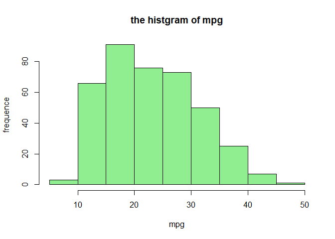

```r
intelPlot(milePerGallon,main = 'the histgram of mpg',xlab = 'mpg',ylab = 'frequence')
```

### 2.data为数值型，设置type=‘histplot’，也会绘制直方图

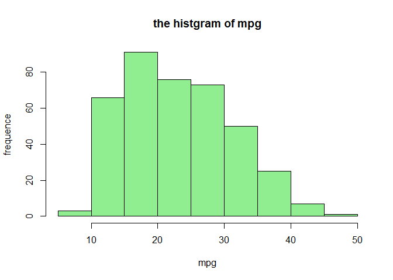

```r
intelPlot(milePerGallon,type = 'histplot',main = 'the histgram of mpg',xlab = 'mpg',ylab = 'frequence')
```

### 3.data为数值型，设置type = ‘histplot’,prob = TRUE,绘制频率直方图

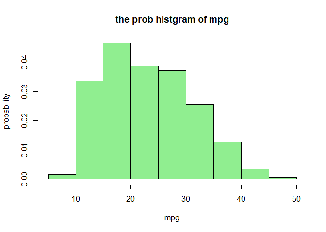

```r
intelPlot(milePerGallon,type = 'histplot',prob = TRUE,main = 'the prob histgram of mpg',xlab = 'mpg',ylab = 'probability')
```

### 4.data为数值型，设置type = ‘histplot’，addlines = TRUE,为直方图添加密度曲线

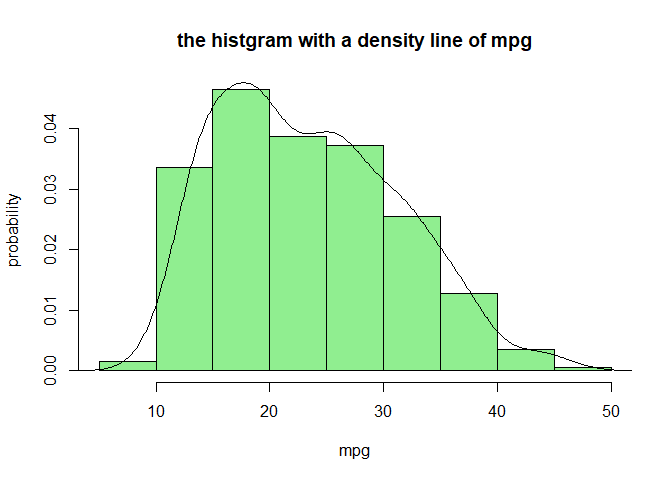

```r
intelPlot(milePerGallon,type = 'histplot',addlines = TRUE,main = 'the histgram with a density line of mpg',xlab = 'mpg',ylab = 'probability')
```

### 5.data为数值型，设置type=‘boxplot’,绘制箱线图

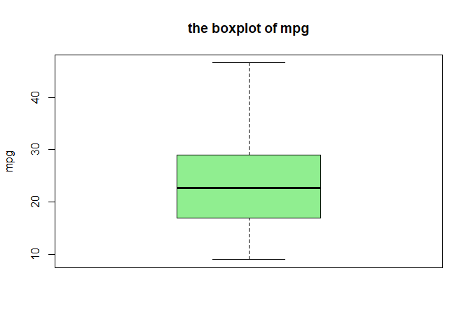

```r
intelPlot(milePerGallon,type = 'boxplot',main = 'the boxplot of mpg',ylab = 'mpg')
```

### 6.data为数值型，设置type=‘stem’,绘制茎叶图

```r
intelPlot(milePerGallon,type = 'stem')
```

```
##
##   The decimal point is at the |
##
##    8 | 0
##   10 | 000000
##   12 | 00000000000000000000000000
##   14 | 00000000000000000005000000000000000055555
##   16 | 000000000000025559000000055555667
##   18 | 00000000000000000112555600000000000012224489
##   20 | 00000000022223555668000000015556
##   22 | 0000000000345000000000257899
##   24 | 0000000000023550000000000144558
##   26 | 0000000000000045668000000000222459
##   28 | 00000000001480000000055889
##   30 | 000000055790000000355689
##   32 | 0000001234478900055578
##   34 | 0011234570017
##   36 | 000000114000237
##   38 | 00001014
##   40 | 85
##   42 | 14
##   44 | 036
##   46 | 6
```

### 5.data为数值型，设置type=‘scatterplot’，绘制散点图

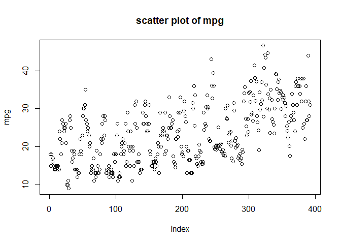

```r
intelPlot(milePerGallon,type = 'scatterplot',ylab = 'mpg',main = 'scatter plot of mpg')
```

### 7.data为字符型，设置type = ‘barplot’,绘制data的频数柱状图

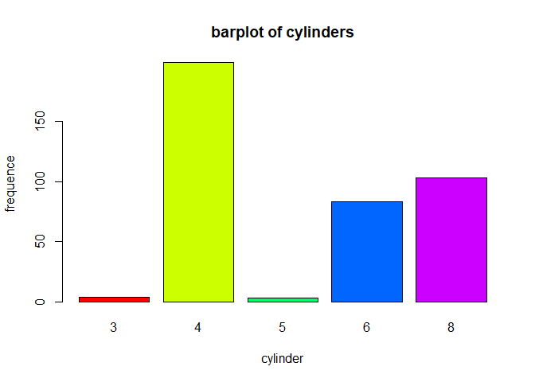

```r
intelPlot(cylinders,type = 'barplot',main = 'barplot of cylinders',xlab = 'cylinder',ylab = 'frequence')
```

### 8.data为字符型，设置type = ‘pie’,绘制data的频数构成饼图

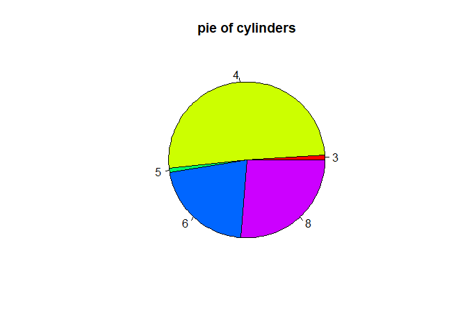

```r
intelPlot(cylinders,type = 'pie',main = 'pie of cylinders')
```

### 9.data为数值型，by为字符型，且by不重复，绘制柱状图

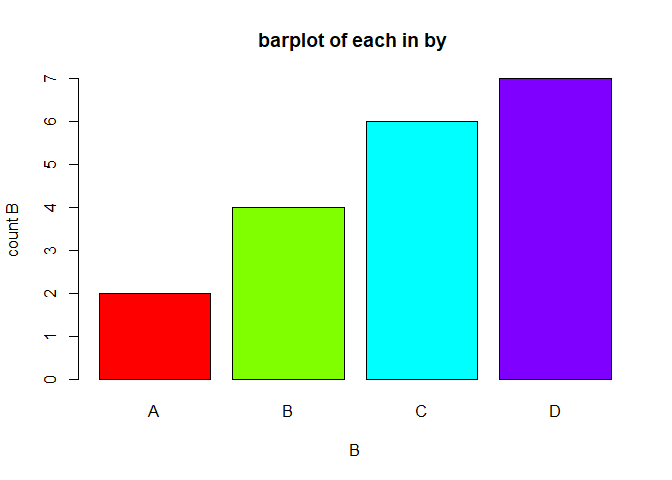

```r
testA <- c(2,4,6,7)
classA <- c('A','B','C','D')
intelPlot(data = testA,by = classA,main = 'barplot of each in by ',xlab = 'B',ylab = 'count B')
```

### 10.data为数值型，by为字符型，且by有重复值，绘制data关于by聚合的柱状图,aggrFun为聚合函数(mean,max,min,median…,any function suitable you want )

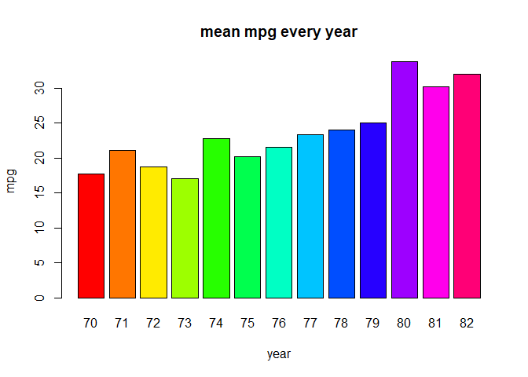

```r
intelPlot(milePerGallon,by = model_year,aggreFun = mean,main= 'mean mpg every year',xlab = 'year',ylab = 'mpg')
```

### 11.data为数值型，by为字符型，且by有重复值，绘制data关于by的箱线图

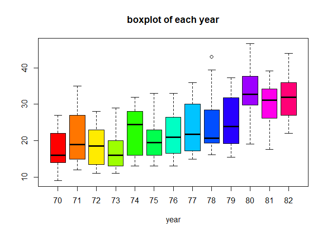

```r
intelPlot(milePerGallon,by = model_year,type = 'boxplot',main = 'boxplot of each year',xlab = 'year',ylab = 'mpg')
```

### 12.data为数值型，by为数值型，设置type = ‘scatterplot’，绘制二维散点图

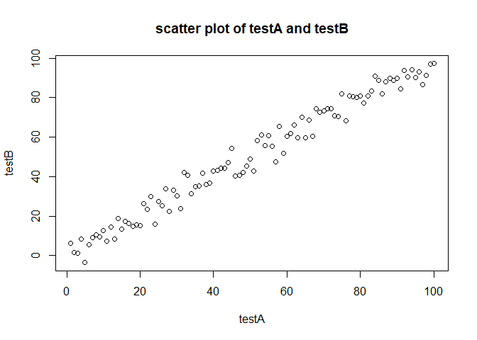

```r
testA <- 1:100
testB <- rnorm(100)*4+(1:100)
intelPlot(testA,testB,type = 'scatterplot',main = 'scatter plot of testA and testB',xlab = 'testA',ylab = 'testB')
```

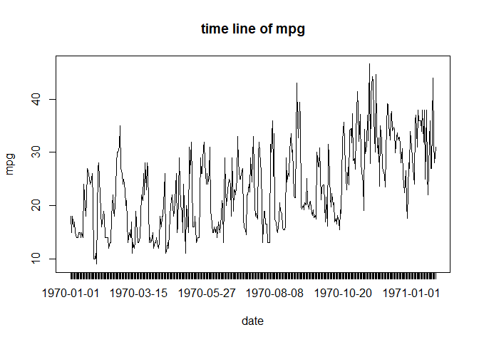

```r
from <- as.Date('1970-01-01')
timeseq <- seq(from = from,by = 1,length.out = 392)
#saleQ <- runif(n = 392,min = 100,max = 150)
intelPlot(data = milePerGallon,by = timeseq,main = 'time line of mpg',xlab = 'date',ylab = 'mpg')
```